# Statistical inference, part I

Introduction to hypothesis testing and mean comparisons

Eva Freyhult

NBIS, SciLifeLab

September 7, 2026

## Introduction to hypothesis tests

**Statistical inference** is to draw conclusions regarding properties of a population based on observations of a random sample from the population.

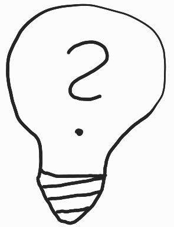

A **hypothesis test** is a type of inference used to evaluate if a hypothesis about a population is supported by the observations of a random sample (i.e by the data available).

Typically, the hypotheses that are tested are assumptions about properties of a population, such as proportion, mean, mean difference, variance etc.

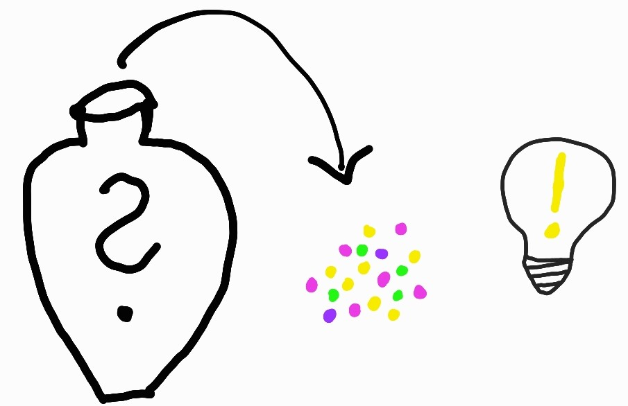

## A first hypothesis test example

In Sweden as a whole, about **30%** of people are allergic to pollen.

We observe **100 people in Uppsala**, and **42** of them are allergic to pollen.

**Question:**  
Is there reason to believe that the true proportion in Uppsala is greater than 0.3?

This is a typical **hypothesis testing** question.

## Null and alternative hypotheses

Let $\pi$ denote the true proportion of pollen allergy in the Uppsala population.

We want to investigate whether the proportion in Uppsala is greater than in Sweden as a whole.

$$H_0:\pi=0.30$$

$$H_1:\pi>0.30$$

- $H_0$: no increase in Uppsala
- $H_1$: higher proportion in Uppsala

## Observed statistic

A simple summary of the sample is the **sample proportion**:

$$p=\frac{x}{n}$$

where

- $x$ = number allergic in the sample
- $n$ = sample size

In our example:

$$x=42,\qquad n=100$$

so

$$p_{obs}=\frac{42}{100}=0.42$$

## What would we expect if $H_0$ were true?

If $H_0$ is true, then the pollen allergy proportion in Uppsala is also 0.30.

Then a sample of 100 people from Uppsala should behave like a random sample where

- 30% are allergic
- 70% are not allergic

So we ask:

**If the true proportion is 0.30, how unusual is an observed sample proportion of 0.42?**

## Simulate under $H_0$ in R

We can simulate many samples of size 100 under the null hypothesis.

```r
set.seed(13)

pnull <- replicate(10000, {
  x <- sample(c(0, 1), size = 100, replace = TRUE, prob = c(0.7, 0.3))
  mean(x)
})
```

Each simulated value is a sample proportion from a world where $H_0$ is true.

## Null distribution

This is an estimated null distribution of the sample proportion.

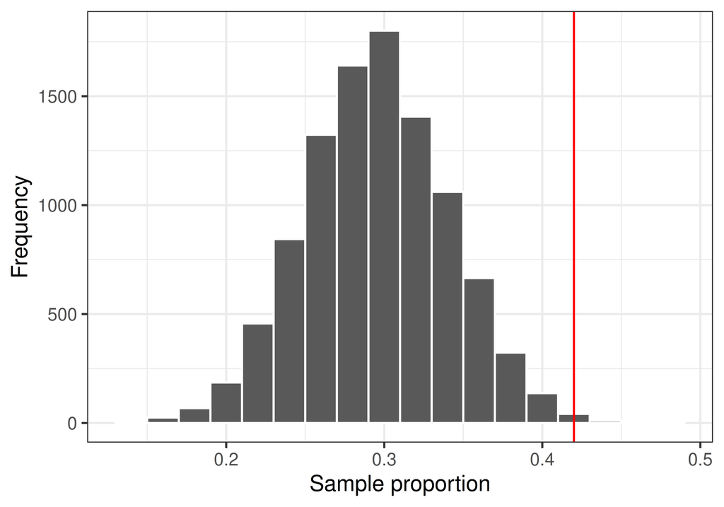

The red line marks the observed value, $p_{obs}=0.42$.

## p-value

The **p-value** is the probability of observing the value we got, or something even more extreme, **if $H_0$ is true**.

Here:

$$p\text{-value}=P(P\geq 0.42\mid H_0)$$

Estimate it from the simulated null distribution:

```r
mean(pnull >= 0.42)
```

```
[1] 0.006
```

If this probability is very small, then the observed result would be unusual under $H_0$.

## Decision

Suppose we use the significance level

$$\alpha=0.05$$

If the p-value is less than 0.05, we reject $H_0$.

Here, the p-value is small, so we reject $H_0$.

**Conclusion:**  
The data provide evidence that the proportion of pollen allergy in Uppsala is greater than 0.30.

## What did we just do?

In this example, we:

1. Defined a **null hypothesis** and an **alternative hypothesis**
2. Computed an **observed statistic**
3. Simulated the **null distribution**
4. Computed a **p-value**
5. Reached a conclusion by comparing the p-value to $\alpha$

This is the basic structure of a **hypothesis test**.

## We were slightly sloppy…

In our first example, we introduced the main idea of a hypothesis test:

- compare the observed result to what we would expect under $H_0$
- compute a p-value
- decide whether the result is surprising under $H_0$

But we skipped one important step:

**the significance level, $\alpha$, should be chosen before looking at the result.**

To perform a hypothesis test properly, we should follow a more careful recipe.

## To perform a hypothesis test

1. Define $H_0$ and $H_1$
2. Select an appropriate significance level, $\alpha$
3. Select appropriate test statistic, $T$, and compute the observed value, $t_{obs}$
4. Assume that $H_0$ is true and compute the sampling distribution of $T$.
5. Compare the observed value, $t_{obs}$, with the computed sampling distribution under $H_0$ and compute a p-value.
6. Based on the p-value either reject or fail to reject $H_0$.

## The null and alternative hypothesis

### Null hypothesis, $H_0$

$H_0$ is in general neutral

- *no change*
- *no difference between groups*
- *no association*

In general we want to show that $H_0$ is false.

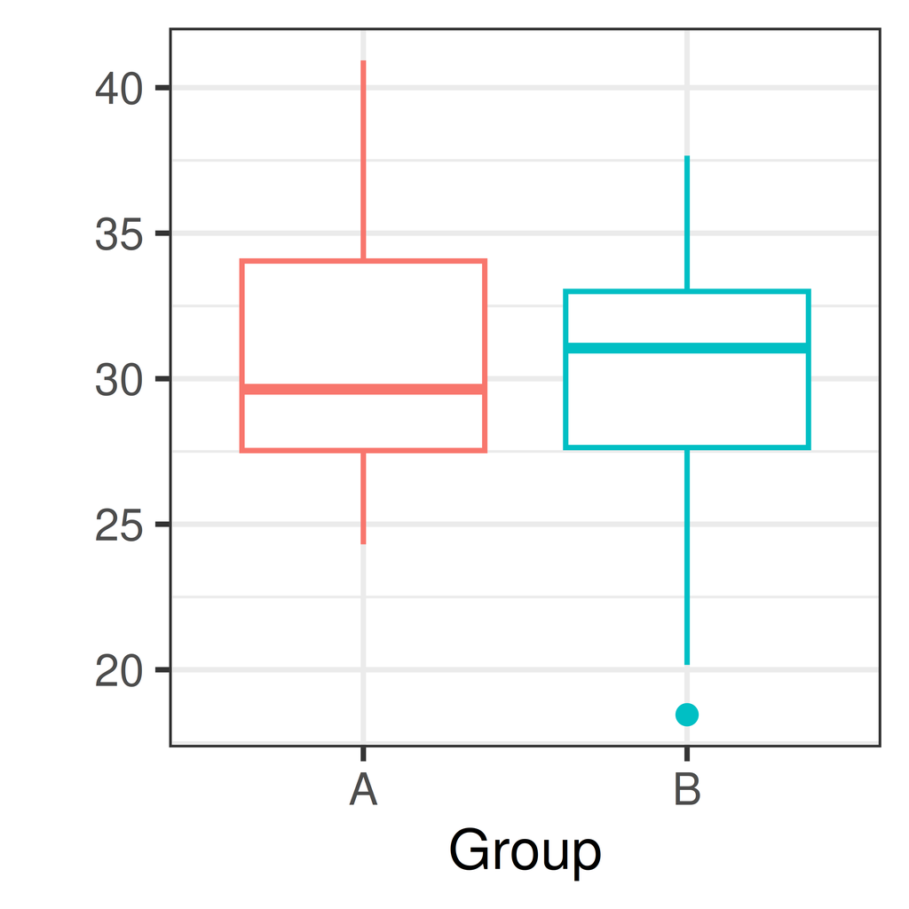

### Alternative hypothesis, $H_1$

$H_1$ expresses what the researcher is interested in

- *the treatment has an effect*
- *there is a difference between groups*
- *there is an association*

The alternative hypothesis can also be directional

- *the treatment has a positive effect*

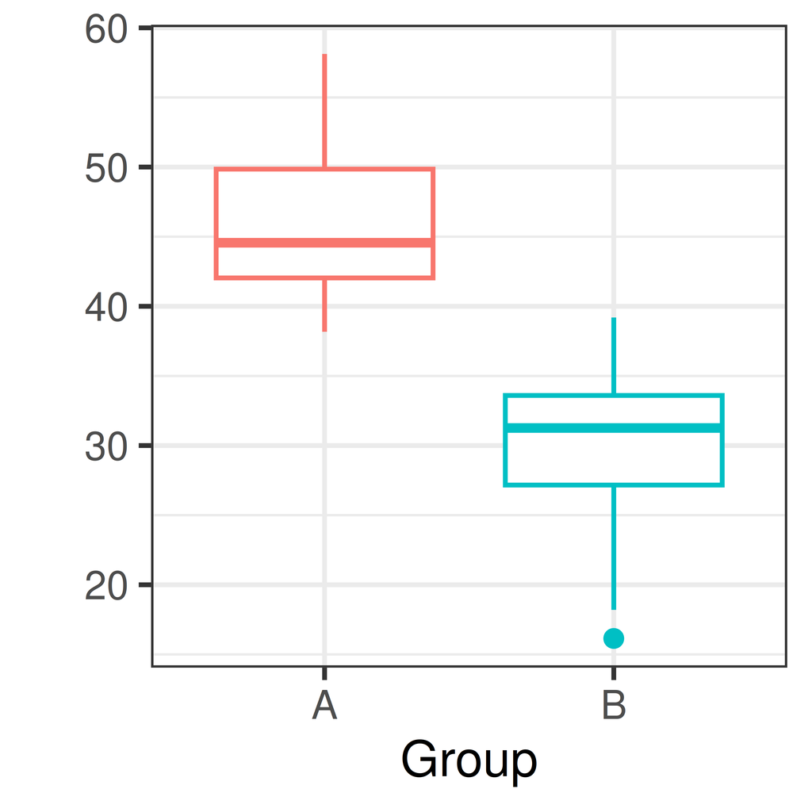

## Null distribution

A **sampling distribution** is the distribution of a sample statistic. The sampling distribution can be obtained by drawing a large number of samples from a specific population.

The **null distribution** is a sampling distribution when the null hypothesis is true.

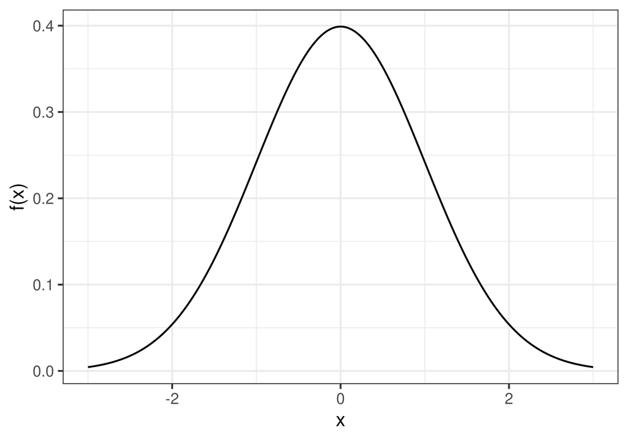

## p-value

The p-value is the probability of the observed value, or something more extreme, if the null hypothesis is true.

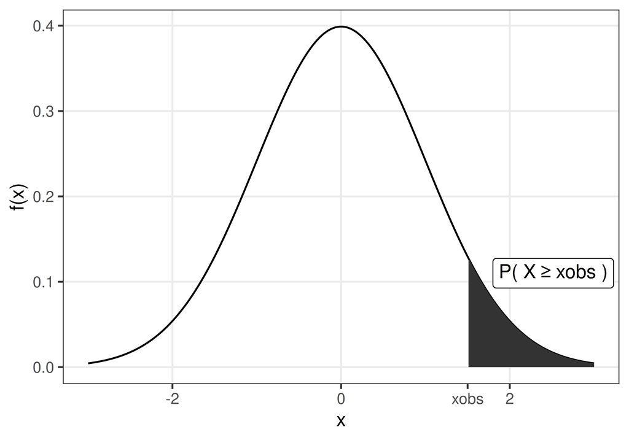

## p-value

The p-value is the probability of the observed value, or something more extreme, if the null hypothesis is true.

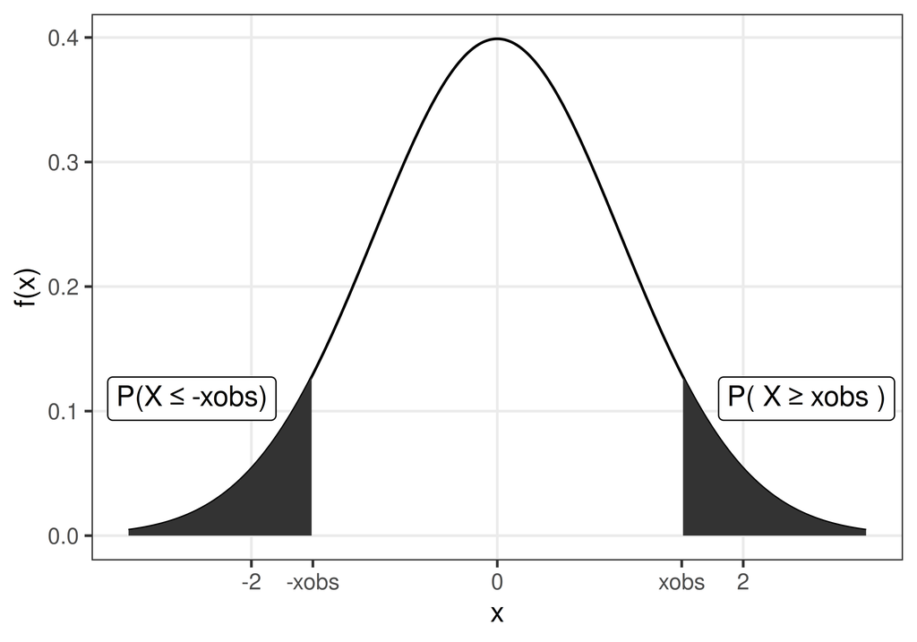

## Significance level

The **significance level**, $\alpha$, is the risk of false alarm.

$\alpha$ should be set before the hypothesis test is performed.

Common values to use are $\alpha=0.05$ or 0.01.

- If the p-value is above the significance level, $p>\alpha$, $H_0$ is not rejected.
- If the p-value is below the significance level, $p \leq \alpha$, $H_0$ is rejected.

## Error types

A hypothesis test is used to draw inference about a population based on a random sample. The inference made might of course be wrong. There are two types of errors;

**Type I error** is a false positive, a false alarm that occurs when $H_0$ is rejected when it is actually true. Examples: *“The test says that you are covid-19 positive, when you actually are not”, “The test says that the drug has a positive effect on patient symptoms, but it actually has not”*.

**Type II error** is a false negative, a miss that occurs when $H_0$ is not rejected, when it is actually false. Examples: *“The test says that you are covid-19 negative, when you actually have covid-19”, “The test says that the drug has no effect on patient symptoms, when it actually has”*.

## Probability of type I and II errors

The probability of type I and II errors are denoted $\alpha$ and $\beta$, respectively.

$$\alpha = P(\textrm{type I error}) = P(\textrm{false alarm}) = P(\textrm{Reject }H_0 \mid H_0 \textrm{ is true})$$
$$\beta = P(\textrm{type II error}) = P(\textrm{miss}) = P(\textrm{Fail to reject }H_0 \mid H_1 \textrm{ is true})$$

The significance level, $\alpha$, is the risk of false alarm.

## Probability of type I and II errors

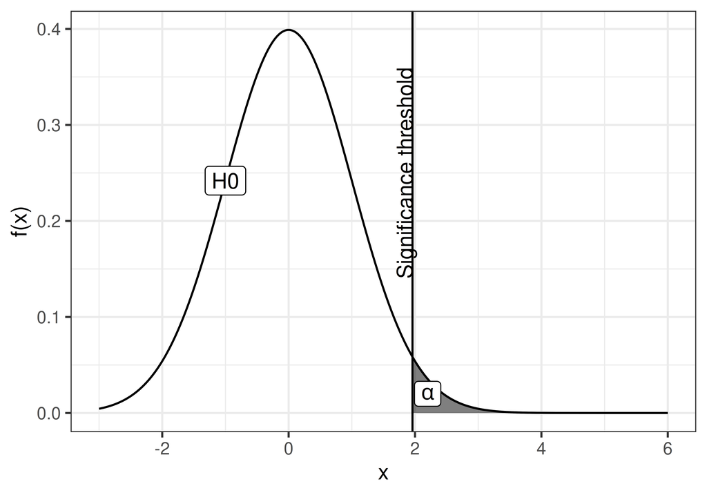

The probability density functions under H0. The probability of type I error ($\alpha$)is indicated.

## Probability of type I and II errors

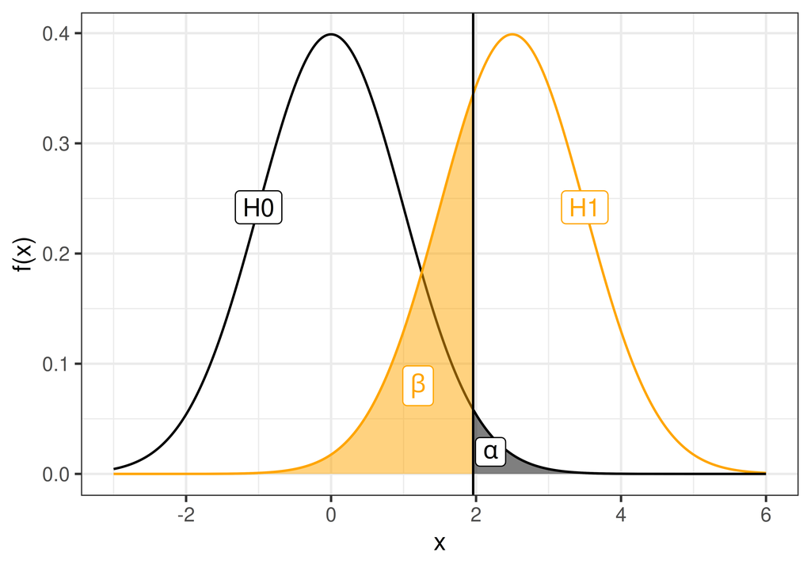

The probability density functions under H0 and H1, respectively. The probability of type I error ($\alpha$) and type II error ($\beta$) are indicated.

## Statistical power

**Statistical power** is defined as

$$\textrm{power} = 1 - \beta = P(\textrm{Reject }H_0 \mid H_1\textrm{ is true}).$$

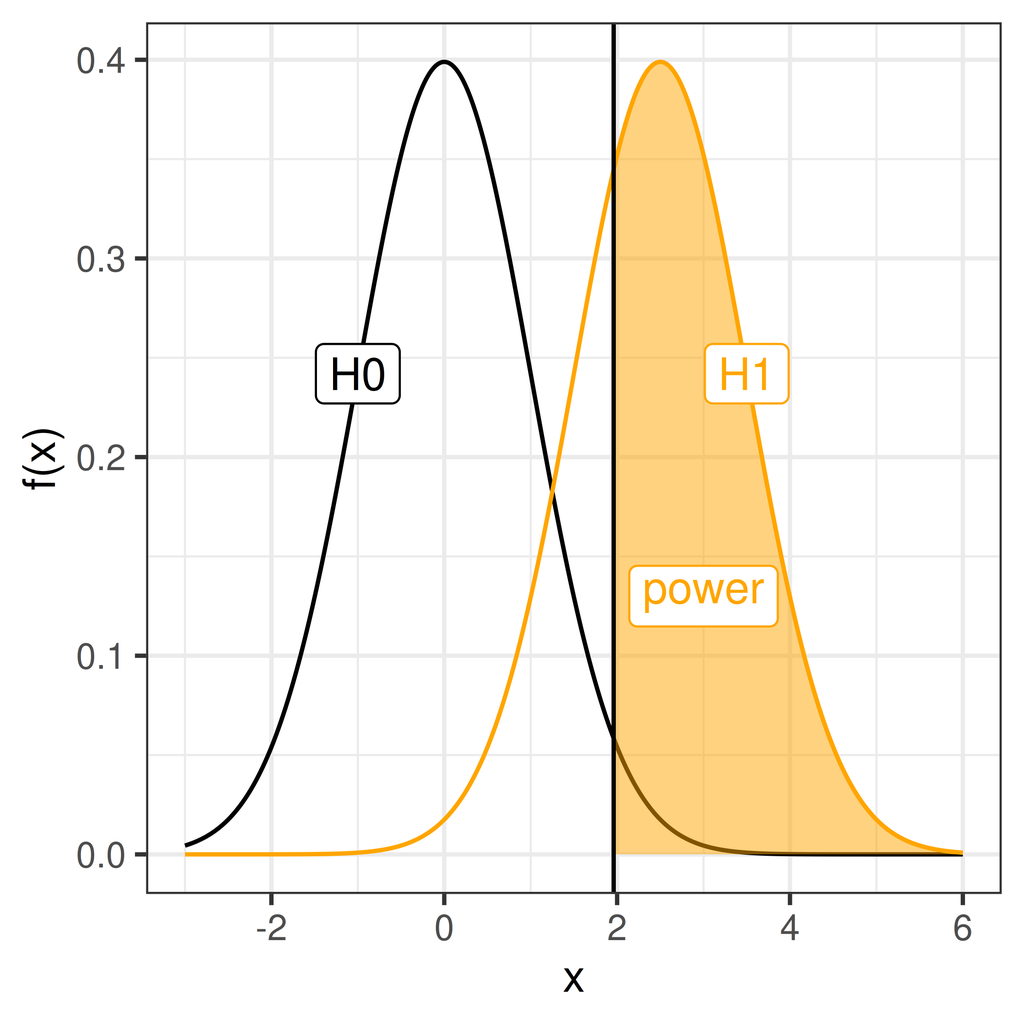

## Hypothesis testing using resampling

The null distribution, the sampling distribution of a test statistic under the null hypothesis, is sometimes known or can be approximated. When the null distribution is unknown, another option is to estimate the null distribution using resampling.

- Simulate from a known $H_0$
- Bootstrap
- Permutation

## Bootstrap

**Bootstrap** is a resampling technique that resamples with replacement from the available data (random sample) to construct new simulated samples.

Bootstrapping can be used to simulate a sampling distribution and estimate properties such as standard error and interval estimates, but also to perform hypothesis testing.

## Permutation

A permutation test answers the question whether an observed effect could be due only to the random sampling, how samples are assigned to different groups for example.

Permutation tests are commonly used in clinical settings where a treatment group is compared to a control group.

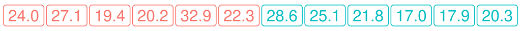

Permute!

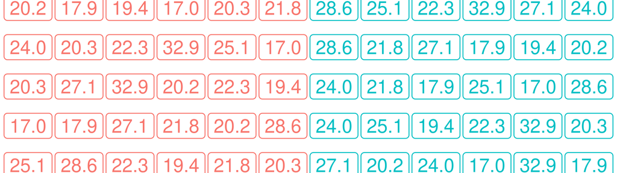

| perm | mA | mB | diff |
| --- | --- | --- | --- |
| 0 | 24 | 22 | 2.57 |
| 1 | 23 | 23 | -0.26 |
| 2 | 22 | 24 | -1.92 |
| 3 | 24 | 22 | 1.30 |
| 4 | 24 | 22 | 1.11 |
| 5 | 19 | 27 | -7.28 |

## Permutation example

**Do high fat diet lead to increased body weight?**

Study setup:

1. Order 24 female mice from a lab.

## Permutation example

**Do high fat diet lead to increased body weight in mice?**

Study setup:

1. Order 24 female mice from a lab.
2. Randomly assign 12 of the 24 mice to receive high-fat diet, the remaining 12 are controls (ordinary diet).

High-fat diet

Ordinary diet

## Permutation example

**Do high fat diet lead to increased body weight in mice?**

Study setup:

1. Order 24 female mice from a lab.
2. Randomly assign 12 of the 24 mice to receive high-fat diet, the remaining 12 are controls (ordinary diet).

High-fat diet

Ordinary diet

3. Measure body weight after three weeks.

## Permutation example

**Do high fat diet lead to increased body weight in mice?**

Study setup:

1. Order 24 female mice from a lab.
2. Randomly assign 12 of the 24 mice to receive high-fat diet, the remaining 12 are controls (ordinary diet).
3. Measure body weight after three weeks.

The observed values, mouse weights in grams, are summarized below;

| high-fat | 25 | 30 | 23 | 18 | 31 | 24 | 39 | 26 | 36 | 29 | 23 | 32 |
| --- | --- | --- | --- | --- | --- | --- | --- | --- | --- | --- | --- | --- |
| ordinary | 27 | 25 | 22 | 23 | 25 | 37 | 24 | 26 | 21 | 26 | 30 | 24 |

## Permutation example

**1. Null and alternative hypotheses**

$$\begin{aligned}
H_0: \mu_{HF} = \mu_{N} \iff \mu_{HF} - \mu_{N} = 0\\
H_1: \mu_{HF}>\mu_{N} \iff \mu_{HF}-\mu_{N} > 0
\end{aligned}$$

where $\mu_{HF}$ is the (unknown) mean body weight of the high-fat mouse population and $\mu_{N}$ is the mean body-weight of the control mouse population.

Studied population: Female mice that can be ordered from a lab.

## Permutation example

**2. Select appropriate significance level** $\alpha$

$$\alpha = 0.05$$

## Permutation example

**3. Test statistic**

Of interest: the mean weight difference between high-fat and control mice

$$D = \bar X_2 - \bar X_1$$

Mean weight of 12 (randomly selected) mice on ordinary diet, $\bar X_1$. $E[\bar X_1] = E[X_1] = \mu_1$

Mean weight of 12 (randomly selected) mice on high-fat diet, $\bar X_2$. $E[\bar X_2] = E[X_2] = \mu_2$

Observed values:

$\bar x_1 = 25.83$, mean weight of control mice (ordinary diet)

$\bar x_2 = 28.00$, mean weight of mice on high-fat diet

$d_{obs} = \bar x_2 - \bar x_1 = 2.17$, difference in mean weights

## Permutation example

**4. Null distribution**

If high-fat diet has no effect, i.e. if $H_0$ were true, the result would be as if all mice were given the same diet.

The 24 mice were initially from the same population. Depending on how the mice are randomly assigned to the high-fat and normal group, the mean weights would differ, even if the two groups were treated the same.

## Permutation example

**4. Null distribution**

If high-fat diet has no effect, i.e. if $H_0$ were true, the result would be as if all mice were given the same diet.

The 24 mice were initially from the same population. Depending on how the mice are randomly assigned to the high-fat and normal group, the mean weights would differ, even if the two groups were treated the same.

## Permutation example

**4. Null distribution**

Random reassignment to two groups can be accomplished using permutation.

Assume $H_0$ is true, i.e. assume all mice are exchangeable, and

1. Randomly reassign 12 of the 24 mice to ‘high-fat’ and the remaining 12 to ‘control’.
2. Compute the difference in mean weights.

If we repeat steps 1 and 2 many times, we get the sampling distribution of the mean difference when $H_0$ is true, that is, the null distribution.

## Permutation example

**4. Null distribution**

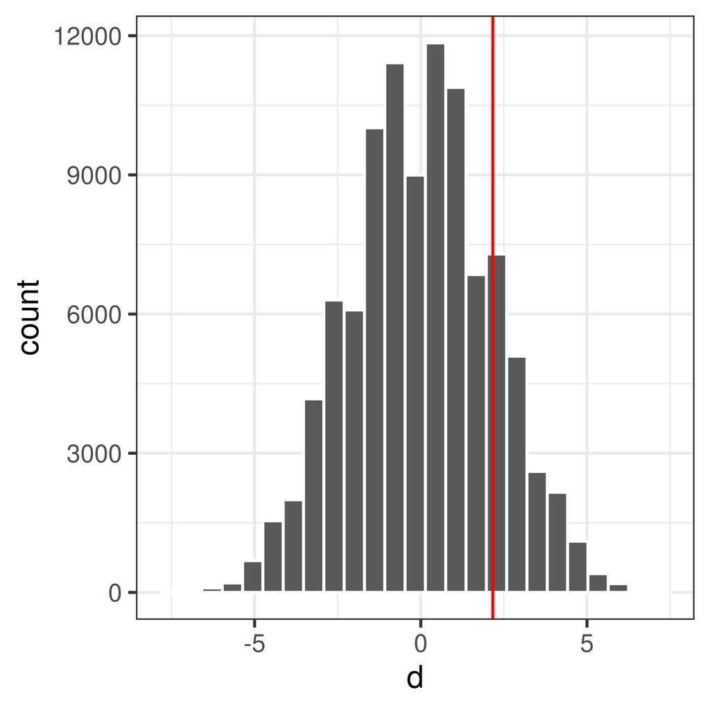

## Permutation example

**5. Compute p-value**

What is the probability to get an at least as extreme mean difference as our observed value, $d_{obs}$, if $H_0$ were true?

$$P(\bar X_2 - \bar X_2 \geq d_{obs} \mid H_0) = 0.169$$

## Permutation example

**6. Conclusion?**

## Parametric tests

If the null distribution was already known (or could be computed based on a few assumptions) resampling would not be necessary.

## Comparing means

Three common situations where means are compared:

- **One sample**: compare the mean of a sample to a prespecified value
- **Two independent samples**: compare the means of two different groups
- **Paired samples**: compare two linked observations, for example before and after treatment in the same individual

These study designs lead to different hypothesis tests.

## One sample, mean

A one sample test of means compares the mean of a sample to a prespecified value.

The hypotheses:

$$H_0: \mu = \mu_0 \\
H_1: \mu \neq \mu_0$$

The alternative hypothesis, $H_1,$ above is for the **two-sided** hypothesis test.

Other options are the **one-sided** alternatives;

- $H_1: \mu > \mu_0$ or
- $H_1: \mu < \mu_0$.

## One sample, mean, mouse example

We know that the weight of a mouse on normal diet is normally distributed with mean 24.0 g and standard deviation 3.0 g. To investigate if body weight of mice is changed by high-fat diet, 10 mice are fed on high-fat diet for three weeks. The mean weight of the high-fat mice is 26.0 g. Is there reason to believe that high-fat diet affects mouse body weight?

## One sample, mean, mouse example

The body weight of a mouse is $X \sim N(\mu, \sigma^2)$, where $\mu=24.0$ and $\sigma=3.0$.

Hence, the mean weight of $n=10$ independent mice from the same population is
$$\bar X \sim N\left(\mu, \frac{\sigma^2}{n}\right).$$

## One sample, mean, mouse example

The body weight of a mouse is $X \sim N(\mu, \sigma),$ where $\mu=24.0$ and $\sigma=3$.

Hence, the mean weight of $n=10$ independent mice from the same population is
$$\bar X \sim N\left(\mu, \frac{\sigma^2}{n}\right).$$

An appropriate test statistic is

$$Z = \frac{\bar X - \mu}{\frac{\sigma}{\sqrt{n}}}$$
If $\sigma$ is known, then $Z\sim N(0,1)$.

## One-sample t-test

For small $n$ and unknown $\sigma$, the test statistic

$$t = \frac{\bar X - \mu}{\frac{s}{\sqrt{n}}}$$

is t-distributed with $df=n-1$ degrees of freedom.

## Two samples, mean

A two-sample test of means is used to determine if two population means are equal.

Two independent samples are collected (one from each population) and the means are compared. This can for example be used to determine if a treatment group differs from a control group in terms of the mean of a property of interest.

The hypotheses:

$$H_0: \mu_2 = \mu_1\\
H_1: \mu_2 \neq \mu_1$$

The above $H_1$ is two-sided. One-sided alternatives could be
$$H_1: \mu_2 > \mu_1\\
\mathrm{or}\\
H_1: \mu_2 < \mu_1$$

## Two samples, mean

Assume that observations from both populations are normally distributed:

$$\begin{aligned}
X_1 \sim N(\mu_1, \sigma_1^2) \\
X_2 \sim N(\mu_2, \sigma_2^2)
\end{aligned}$$

Then it follows that the sample means will also be normally distributed;

$$\begin{aligned}
\bar X_1 \sim N\left(\mu_1, \frac{\sigma_1^2}{n_1}\right) \\
\bar X_2 \sim N\left(\mu_2, \frac{\sigma_2^2}{n_2}\right)
\end{aligned}$$

The mean difference $D = \bar X_2 - \bar X_1$ is thus also normally distributed:

$$D = \bar X_2 - \bar X_1 \sim N\left(\mu_2-\mu_1, \frac{\sigma_2^2}{n_2} + \frac{\sigma_1^2}{n_1}\right)$$

## Two samples, mean

If $H_0$ is true:

$$D = \bar X_2 - \bar X_1 \sim N\left(0, \frac{\sigma_2^2}{n_2} + \frac{\sigma_1^2}{n_1}\right)$$

The test statistic:

$$Z = \frac{\bar X_2 - \bar X_1}{\sqrt{\frac{\sigma_2^2}{n_2} + \frac{\sigma_1^2}{n_1}}}$$
is standard normal, i.e. $Z \sim N(0,1)$.

However, note that the test statistic requires the standard deviations $\sigma_1$ and $\sigma_2$ to be known.

## Two samples, mean

### Unknown variances

What if the population standard deviations are not known?

## Two samples, mean

### Unknown variances, large sample sizes

If the sample sizes are large, we can replace the population standard deviations by the sample standard deviations and, according to the central limit theorem, assume that

$$Z = \frac{\bar X_2 - \bar X_1}{\sqrt{\frac{s_2^2}{n_2} + \frac{s_1^2}{n_1}}} \sim N(0,1)$$

and proceed as before.

## Two samples, mean

### Unknown variances, small sample sizes

$$t = \frac{\bar X_2 - \bar X_1}{\sqrt{\frac{s_2^2}{n_2} + \frac{s_1^2}{n_1}}}$$
is t-distributed.

If equal variances can be assumed, Student’s t-test can be used; otherwise Welch’s t-test for unequal variances is used.

## Two samples, mean

### Unknown equal variances, small sample sizes

**Student’s t-test**

Assume equal variances in the two populations and compute the pooled sample variance:

$$s_p^2 = \frac{(n_1-1)s_1^2 + (n_2-1)s_2^2}{n_1+n_2-2}$$

and the test statistic

$$t = \frac{\bar X_1 - \bar X_2}{\sqrt{s_p^2\left(\frac{1}{n_1} + \frac{1}{n_2}\right)}},$$

which is t-distributed with $n_1+n_2-2$ degrees of freedom.

## Two samples, mean

### Unknown variances, small sample sizes

**Welch’s t-test**

For unequal variances the test statistic is

$$t = \frac{\bar X_2 - \bar X_1}{\sqrt{\frac{s_2^2}{n_2} + \frac{s_1^2}{n_1}}}$$
$t$ is $t$-distributed and the degrees of freedom are approximated using Welch’s method.

The degrees of freedom are approximated using Welch’s method.

Fortunately, the t-test is implemented in R, for example in the function `t.test` in the `stats` package. This function can compute both Student’s t-test with equal variances and Welch’s t-test with unequal variances.

## Paired samples

Sometimes two observations are naturally linked, rather than coming from two independent groups. This happens, for example, in before-and-after studies where the same subjects are measured twice, or in matched study designs.

Examples of paired data include:

- measurements before and after treatment in the same patient
- observations on matched case-control pairs

In a paired design, the analysis should take the pairing into account.

## Paired t-test

The null hypothesis in a paired analysis is that the mean within-pair difference is zero.

Let the paired observations be $(X_{i1}, X_{i2})$ and define the within-pair differences

$$D_i = X_{i2} - X_{i1}.$$

The hypotheses are

$$H_0: \mu_D = 0$$
$$H_1: \mu_D \neq 0$$

The paired t-test is simply a one-sample t-test applied to the differences $D_1, D_2, \dots, D_n$.

$$T = \frac{\bar D}{s_D/\sqrt{n}}$$

## Independent or paired?

| Study design | Typical question | Test |
| --- | --- | --- |
| One sample | Is the mean different from a reference value? | One-sample t-test |
| Two independent groups | Do the two group means differ? | Two-sample t-test |
| Paired samples | Is the mean change/difference within pairs zero? | Paired t-test |

The choice of test depends on the study design.